# Advanced Data Visualizations

West - Week 3

Author

Jeff Goseland

Published

November 22, 2025

## Week 3 Homework

## Part A

```r
#loads needed libraries
suppressMessages({
  library(tidyverse)
  library(RColorBrewer)
  library(sf)
  library(ggmap)
  library(leaflet)
  library(keyring)
  library(htmltools)
  library(Polychrome)
})
```

#### 1. Load spacial data from a shapefile into R

```r
filename <- '../data/School_Boundaries.shp'

school_boundaries_shp <- st_read(filename, stringsAsFactors = FALSE)
```

```r
summary(school_boundaries_shp)
```

```
    School           SchoolType           OBJECTID              geometry
 Length:57          Length:57          Min.   :  6.0   MULTIPOLYGON :57
 Class :character   Class :character   1st Qu.: 67.0   epsg:4326    : 0
 Mode  :character   Mode  :character   Median :118.0   +proj=long...: 0
                                       Mean   :141.1
                                       3rd Qu.:165.0
                                       Max.   :548.0
```

```r
school_boundaries_shp[1,0]
```

|  | geometry |
| --- | --- |
| 1 |  |

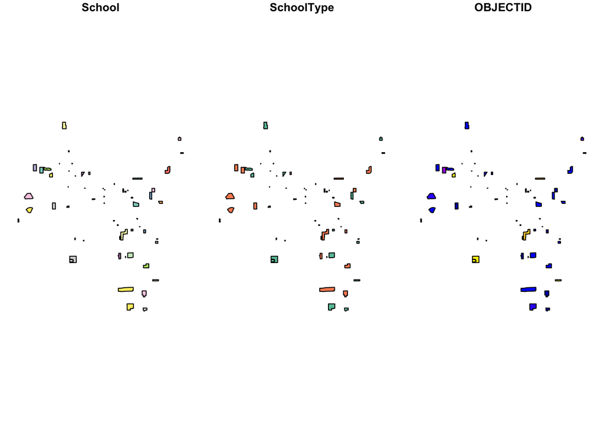

```r
plot(school_boundaries_shp)
```

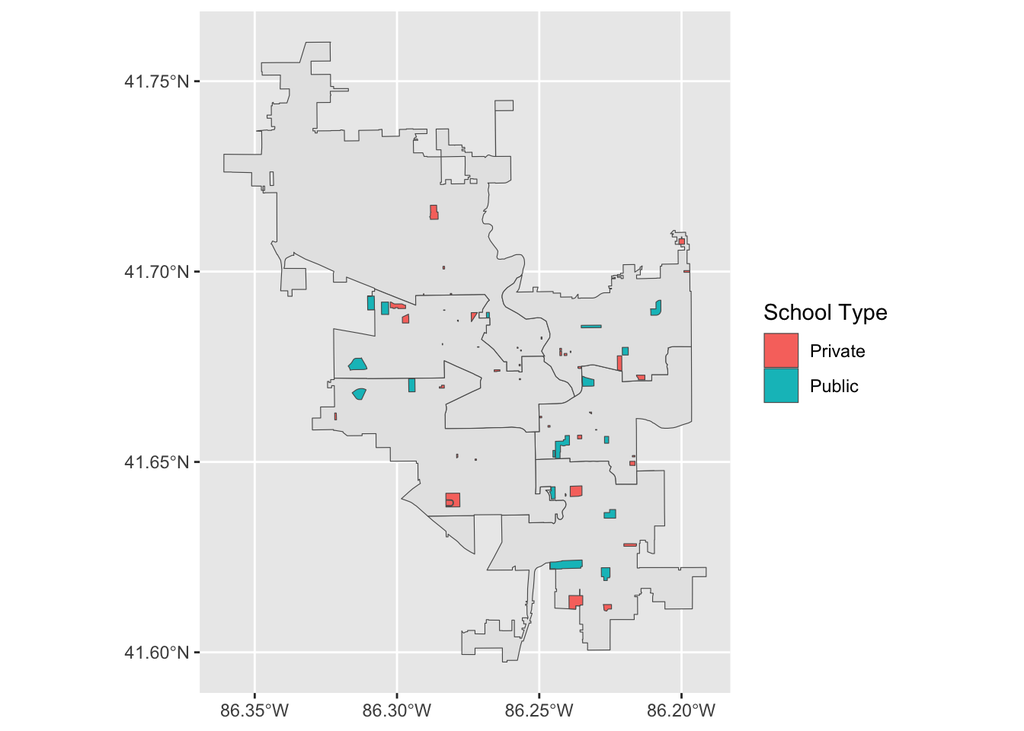

```r
# I don't know if we were supposed to do this but the data looks way better
# with the district latyer underneath it for context
districts <- st_read("../data/City_Council_Districts.shp", stringsAsFactors = FALSE)
ggplot() +
   geom_sf(data = districts) +
  geom_sf(data = school_boundaries_shp$geometry,
          aes(fill = school_boundaries_shp$SchoolType)) +
  labs(fill = "School Type")
```

#### 2. Create a spatial data frame from a table of latitude and longitudes

- Include the code you used to load the csv;
- Include the code you used to convert it to a spatial data frame;
- Include the output of the summary() command run on the spatial data frame; and
- Create a static map with the colors of the features reflecting some variable.

```r
# loading the data
features_points <- read.csv("../data/Parks_Locations_and_Features.csv")


# getting the lat/long
features_spacial <- features_points %>%
                    st_as_sf(coords = c("Lon","Lat")) %>%
                    st_set_crs(value = 4326)

summary(features_spacial)
```

```
  Park_Name          Park_Type            Zip_Code     Aqua_Feat__Pool
 Length:62          Length:62          Min.   :46601   Min.   :1
 Class :character   Class :character   1st Qu.:46614   1st Qu.:1
 Mode  :character   Mode  :character   Median :46616   Median :1
                                       Mean   :46617   Mean   :1
                                       3rd Qu.:46619   3rd Qu.:1
                                       Max.   :46635   Max.   :1
                                                       NA's   :60
 Aqua_Feat__Spray Backstop__Practice   Ballfield       Basketball
 Min.   :1        Min.   :1          Min.   :1.000   Min.   :0.50
 1st Qu.:1        1st Qu.:1          1st Qu.:1.000   1st Qu.:0.50
 Median :1        Median :1          Median :1.000   Median :1.00
 Mean   :1        Mean   :1          Mean   :1.769   Mean   :1.25
 3rd Qu.:1        3rd Qu.:1          3rd Qu.:2.000   3rd Qu.:2.00
 Max.   :1        Max.   :1          Max.   :7.000   Max.   :4.00
 NA's   :57       NA's   :59         NA's   :49      NA's   :46
    Blueway   Complex__Ballfield Complex__Tennis  Concessions   Disk_Golf
 Min.   :1    Min.   :1          Min.   :1       Min.   :1    Min.   :1
 1st Qu.:1    1st Qu.:1          1st Qu.:1       1st Qu.:1    1st Qu.:1
 Median :1    Median :1          Median :1       Median :1    Median :1
 Mean   :1    Mean   :1          Mean   :1       Mean   :1    Mean   :1
 3rd Qu.:1    3rd Qu.:1          3rd Qu.:1       3rd Qu.:1    3rd Qu.:1
 Max.   :1    Max.   :1          Max.   :1       Max.   :1    Max.   :1
 NA's   :61   NA's   :61         NA's   :61      NA's   :60   NA's   :61
 Driving_Range Educational_Experience  Event_Space Fitness_Course
 Min.   :1     Min.   :1              Min.   :1    Min.   :1
 1st Qu.:1     1st Qu.:1              1st Qu.:1    1st Qu.:1
 Median :1     Median :1              Median :1    Median :1
 Mean   :1     Mean   :1              Mean   :1    Mean   :1
 3rd Qu.:1     3rd Qu.:1              3rd Qu.:1    3rd Qu.:1
 Max.   :1     Max.   :1              Max.   :1    Max.   :1
 NA's   :61    NA's   :54             NA's   :57   NA's   :61
 Garden__Community Garden__Display      Golf        Hockey__Ice   Loop_Walk
 Min.   :1         Min.   :1.000   Min.   :0.500   Min.   :1    Min.   :1.00
 1st Qu.:1         1st Qu.:1.500   1st Qu.:0.875   1st Qu.:1    1st Qu.:1.00
 Median :1         Median :2.000   Median :1.000   Median :1    Median :1.00
 Mean   :1         Mean   :1.667   Mean   :0.875   Mean   :1    Mean   :1.25
 3rd Qu.:1         3rd Qu.:2.000   3rd Qu.:1.000   3rd Qu.:1    3rd Qu.:1.00
 Max.   :1         Max.   :2.000   Max.   :1.000   Max.   :1    Max.   :3.00
 NA's   :59        NA's   :59      NA's   :58      NA's   :61   NA's   :54
```

[output cut: 37 more lines]

```
 3rd Qu.:1.0   3rd Qu.: 4.000   3rd Qu.:1
 Max.   :2.0   Max.   :15.000   Max.   :1
 NA's   :57    NA's   :49       NA's   :61
 Water_Access__Developed Water_Access__General Water_Feature   Address
 Min.   :1.00            Min.   :1             Min.   :1     Length:62
 1st Qu.:1.00            1st Qu.:1             1st Qu.:1     Class :character
 Median :1.00            Median :1             Median :1     Mode  :character
 Mean   :1.25            Mean   :1             Mean   :1
 3rd Qu.:1.25            3rd Qu.:1             3rd Qu.:1
 Max.   :2.00            Max.   :1             Max.   :1
 NA's   :54              NA's   :55            NA's   :61
          geometry
 POINT        :62
 epsg:4326    : 0
 +proj=long...: 0
```

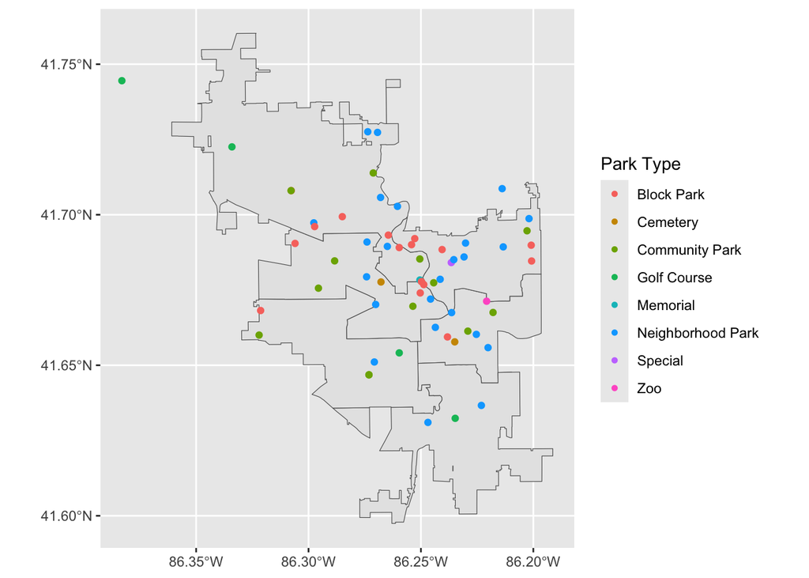

```r
ggplot() +
  geom_sf(data = districts) +
  geom_sf(data = features_spacial,
          aes(col = Park_Type)) +
  guides(col = guide_legend(override.aes = list(shape = 16))) +
  labs(col = "Park Type")
```

## Part B

#### 1. Use the ggmaps package to geocode your subset. Use the output = “more” option.

- Alternatively, you may use the tidygeocoder package.

```r
#registering gkey
# key_set_with_value("google_api", password = "har-har-har")
register_google(key = key_get("google_api"))

# loading the data
business_licenses <- read.csv("../data/Goseland_Business_Licenses_9.csv")
```

#### 2. Save the final data frame as a .csv (with the field names lat, lon, and loctype appended onto the original data). Submit this .csv.

```r
# get geocode using 'more' option
print("I'm starting.....")
```

```
[1] "I'm starting....."
```

```r
geo_data <- business_licenses %>%
            mutate_geocode(Full_Address, output = "more")
print("I'm finished.....")
```

```
[1] "I'm finished....."
```

```r
write_csv(geo_data, "./goseland_geocoded_output.csv")
```

## Part C

```r
# with so many categories I need to a way to make distinct colors
# and this worked well -- used google here to find a way
distinct_colors <- createPalette(length(unique(geo_data$Classification_Description)),
                                 c("#ff0000", "#00ff00", "#0000ff"))

# this part I had to do some google and claude help
# I tried to do it inline and had lots of failures
color_palette <- colorFactor(palette = distinct_colors,
                             domain = geo_data$Classification_Description)

leaflet(geo_data) %>%
    addTiles(group = 'Street Map') %>%
    addCircleMarkers(lng = ~lon, lat = ~lat,
                     color = ~color_palette(Classification_Description), # here
                     fillOpacity = 1,
                     radius = 4,
                     stroke = FALSE,
                     weight = 1,
                     popup = ~paste0(
                       "<b>", Business_Name, "</b><br/>",
                       Classification_Description, "<br/>",
                       Street_Address),
                     label = ~Business_Name) %>%
  addLegend( position = "bottomright",
             pal = color_palette, #here
             values = ~Classification_Description,
             title = "Business Classification",
             opacity = 1) %>%
   # the legend was too big so I used Claude to help me find a way to
   # make it smaller
   htmlwidgets::onRender("
      function(el, x) {
        var legend = el.querySelector('.legend');
        if(legend) {
          legend.style.fontSize = '10px';
          legend.style.maxHeight = '400px';
          legend.style.overflowY = 'auto';
        }
      }
    ")
```

[interactive chart not shown]

#### 1. Write a paragraph explaining what you are showing, why you made particular design choices, and how it could be useful for the audience/user.

This is a map of the South Bend area with the businesses and types of businesses plotted by classification. There were so many classifications that I found a way to make very distinct colors as all of the other palettes were creating gradients and hues of the same colors making distinction very hard.

Also because of the number of classifications, I found a way to make the legend smaller. I think both of the choices on the classifications makes it easier for the map consumer to use it.

#### 2. Include the Leaflet code used to generate the map in a PDF or HTML file.